# EDA - Home Credit

Sterling LeDuc - u0767552

02/16/2025

# Introduction

Many trustworthy and financially stable individuals have trouble getting approved for loans because they have insufficient (or non-existent) credit histories. This can cause lenders to lose valuable business and borrowers to miss out on financial opportunities.

Home Credit has devised a strategy to broaden the scope of lending inclusion by utilizing alternative financial data, including transactional data, to find credit-lacking clients that are capable of loan repayment. This can grant them additional business that other lenders would otherwise miss out on.

## Data Review Goals

Questions we want to ask as we examine the data: - Are there any values that don’t make sense? - Are there outliers that might skew the data? - Are there missing values? If so, how should they be handled? - Are the data types appropriate? - Which variables affect the target the most? - Are there duplicate variables? - Are there variables we can ignore?

Primary goal is to generate predictions on the test data set and validate our predictions with a Kaggle score. The higher our accuracy the better.

# Loading Packages and Data

# Loading Main Data

```r
#Loading full test and train data

test <- read_csv("application_test.csv")
train <- read_csv("application_train.csv")
```

## Sampling and Examining Data

In this section we will take a broad look at the data.

```r
#Combining data sets to make cleaning easier:

test |> mutate(TARGET = 2) -> test

train_samp <- rbind(train, test)

#Showing first 10 lines of the data:

train_samp |> head(n=10)
```

```
## # A tibble: 10 x 122
##    SK_ID_CURR TARGET NAME_CONTRACT_TYPE CODE_GENDER FLAG_OWN_CAR FLAG_OWN_REALTY
##         <dbl>  <dbl> <chr>              <chr>       <chr>        <chr>
##  1     100002      1 Cash loans         M           N            Y
##  2     100003      0 Cash loans         F           N            N
##  3     100004      0 Revolving loans    M           Y            Y
##  4     100006      0 Cash loans         F           N            Y
##  5     100007      0 Cash loans         M           N            Y
##  6     100008      0 Cash loans         M           N            Y
##  7     100009      0 Cash loans         F           Y            Y
##  8     100010      0 Cash loans         M           Y            Y
##  9     100011      0 Cash loans         F           N            Y
## 10     100012      0 Revolving loans    M           N            Y
## # i 116 more variables: CNT_CHILDREN <dbl>, AMT_INCOME_TOTAL <dbl>,
## #   AMT_CREDIT <dbl>, AMT_ANNUITY <dbl>, AMT_GOODS_PRICE <dbl>,
## #   NAME_TYPE_SUITE <chr>, NAME_INCOME_TYPE <chr>, NAME_EDUCATION_TYPE <chr>,
## #   NAME_FAMILY_STATUS <chr>, NAME_HOUSING_TYPE <chr>,
## #   REGION_POPULATION_RELATIVE <dbl>, DAYS_BIRTH <dbl>, DAYS_EMPLOYED <dbl>,
## #   DAYS_REGISTRATION <dbl>, DAYS_ID_PUBLISH <dbl>, OWN_CAR_AGE <dbl>,
## #   FLAG_MOBIL <dbl>, FLAG_EMP_PHONE <dbl>, FLAG_WORK_PHONE <dbl>, ...
```

```r
skim(train_samp)
```

Data summary

| Name | train_samp |
| --- | --- |
| Number of rows | 356255 |
| Number of columns | 122 |
| _______________________ |  |
| Column type frequency: |  |
| character | 16 |
| numeric | 106 |
| ________________________ |  |
| Group variables | None |

**Variable type: character**

| skim_variable | n_missing | complete_rate | min | max | empty | n_unique | whitespace |
| --- | --- | --- | --- | --- | --- | --- | --- |
| NAME_CONTRACT_TYPE | 0 | 1.00 | 10 | 15 | 0 | 2 | 0 |
| CODE_GENDER | 0 | 1.00 | 1 | 3 | 0 | 3 | 0 |
| FLAG_OWN_CAR | 0 | 1.00 | 1 | 1 | 0 | 2 | 0 |
| FLAG_OWN_REALTY | 0 | 1.00 | 1 | 1 | 0 | 2 | 0 |
| NAME_TYPE_SUITE | 2203 | 0.99 | 6 | 15 | 0 | 7 | 0 |
| NAME_INCOME_TYPE | 0 | 1.00 | 7 | 20 | 0 | 8 | 0 |
| NAME_EDUCATION_TYPE | 0 | 1.00 | 15 | 29 | 0 | 5 | 0 |
| NAME_FAMILY_STATUS | 0 | 1.00 | 5 | 20 | 0 | 6 | 0 |
| NAME_HOUSING_TYPE | 0 | 1.00 | 12 | 19 | 0 | 6 | 0 |
| OCCUPATION_TYPE | 111996 | 0.69 | 7 | 21 | 0 | 18 | 0 |
| WEEKDAY_APPR_PROCESS_START | 0 | 1.00 | 6 | 9 | 0 | 7 | 0 |
| ORGANIZATION_TYPE | 0 | 1.00 | 3 | 22 | 0 | 58 | 0 |
| FONDKAPREMONT_MODE | 243092 | 0.32 | 13 | 21 | 0 | 4 | 0 |
| HOUSETYPE_MODE | 177916 | 0.50 | 14 | 16 | 0 | 3 | 0 |
| WALLSMATERIAL_MODE | 180234 | 0.49 | 5 | 12 | 0 | 7 | 0 |
| EMERGENCYSTATE_MODE | 167964 | 0.53 | 2 | 3 | 0 | 2 | 0 |

**Variable type: numeric**

| skim_variable | n_missing | complete_rate | mean | sd | p0 | p25 | p50 | p75 | p100 | hist |
| --- | --- | --- | --- | --- | --- | --- | --- | --- | --- | --- |
| SK_ID_CURR | 0 | 1.00 | 278128.00 | 102842.10 | 100001.00 | 189064.50 | 278128.00 | 367191.50 | 456255.00 | ▇▇▇▇▇ |
| TARGET | 0 | 1.00 | 0.34 | 0.71 | 0.00 | 0.00 | 0.00 | 0.00 | 2.00 | ▇▁▁▁▂ |
| CNT_CHILDREN | 0 | 1.00 | 0.41 | 0.72 | 0.00 | 0.00 | 0.00 | 1.00 | 20.00 | ▇▁▁▁▁ |
| AMT_INCOME_TOTAL | 0 | 1.00 | 170116.06 | 223506.82 | 25650.00 | 112500.00 | 153000.00 | 202500.00 | 117000000.00 | ▇▁▁▁▁ |
| AMT_CREDIT | 0 | 1.00 | 587767.41 | 398623.69 | 45000.00 | 270000.00 | 500211.00 | 797557.50 | 4050000.00 | ▇▂▁▁▁ |
| AMT_ANNUITY | 36 | 1.00 | 27425.56 | 14732.81 | 1615.50 | 16731.00 | 25078.50 | 34960.50 | 258025.50 | ▇▁▁▁▁ |
| AMT_GOODS_PRICE | 278 | 1.00 | 528020.00 | 366064.99 | 40500.00 | 234000.00 | 450000.00 | 675000.00 | 4050000.00 | ▇▂▁▁▁ |
| REGION_POPULATION_RELATIVE | 0 | 1.00 | 0.02 | 0.01 | 0.00 | 0.01 | 0.02 | 0.03 | 0.07 | ▇▇▃▁▁ |
| DAYS_BIRTH | 0 | 1.00 | -16041.25 | 4358.80 | -25229.00 | -19676.00 | -15755.00 | -12425.00 | -7338.00 | ▃▆▇▇▅ |
| DAYS_EMPLOYED | 0 | 1.00 | 64317.23 | 141705.53 | -17912.00 | -2781.00 | -1224.00 | -290.00 | 365243.00 | ▇▁▁▁▂ |
| DAYS_REGISTRATION | 0 | 1.00 | -4983.59 | 3526.97 | -24672.00 | -7477.00 | -4502.00 | -1995.00 | 0.00 | ▁▁▂▅▇ |
| DAYS_ID_PUBLISH | 0 | 1.00 | -3002.07 | 1517.90 | -7197.00 | -4318.00 | -3252.00 | -1717.00 | 0.00 | ▁▆▇▆▆ |
| OWN_CAR_AGE | 235241 | 0.34 | 12.02 | 11.88 | 0.00 | 5.00 | 9.00 | 15.00 | 91.00 | ▇▁▁▁▁ |
| FLAG_MOBIL | 0 | 1.00 | 1.00 | 0.00 | 0.00 | 1.00 | 1.00 | 1.00 | 1.00 | ▁▁▁▁▇ |
| FLAG_EMP_PHONE | 0 | 1.00 | 0.82 | 0.39 | 0.00 | 1.00 | 1.00 | 1.00 | 1.00 | ▂▁▁▁▇ |
| FLAG_WORK_PHONE | 0 | 1.00 | 0.20 | 0.40 | 0.00 | 0.00 | 0.00 | 0.00 | 1.00 | ▇▁▁▁▂ |
| FLAG_CONT_MOBILE | 0 | 1.00 | 1.00 | 0.04 | 0.00 | 1.00 | 1.00 | 1.00 | 1.00 | ▁▁▁▁▇ |
| FLAG_PHONE | 0 | 1.00 | 0.28 | 0.45 | 0.00 | 0.00 | 0.00 | 1.00 | 1.00 | ▇▁▁▁▃ |
| FLAG_EMAIL | 0 | 1.00 | 0.07 | 0.26 | 0.00 | 0.00 | 0.00 | 0.00 | 1.00 | ▇▁▁▁▁ |
| CNT_FAM_MEMBERS | 2 | 1.00 | 2.15 | 0.91 | 1.00 | 2.00 | 2.00 | 3.00 | 21.00 | ▇▁▁▁▁ |
| REGION_RATING_CLIENT | 0 | 1.00 | 2.05 | 0.51 | 1.00 | 2.00 | 2.00 | 2.00 | 3.00 | ▁▁▇▁▂ |
| REGION_RATING_CLIENT_W_CITY | 0 | 1.00 | 2.03 | 0.50 | -1.00 | 2.00 | 2.00 | 2.00 | 3.00 | ▁▁▁▇▂ |
| HOUR_APPR_PROCESS_START | 0 | 1.00 | 12.06 | 3.27 | 0.00 | 10.00 | 12.00 | 14.00 | 23.00 | ▁▃▇▆▁ |
| REG_REGION_NOT_LIVE_REGION | 0 | 1.00 | 0.02 | 0.12 | 0.00 | 0.00 | 0.00 | 0.00 | 1.00 | ▇▁▁▁▁ |
| REG_REGION_NOT_WORK_REGION | 0 | 1.00 | 0.05 | 0.22 | 0.00 | 0.00 | 0.00 | 0.00 | 1.00 | ▇▁▁▁▁ |
| LIVE_REGION_NOT_WORK_REGION | 0 | 1.00 | 0.04 | 0.20 | 0.00 | 0.00 | 0.00 | 0.00 | 1.00 | ▇▁▁▁▁ |
| REG_CITY_NOT_LIVE_CITY | 0 | 1.00 | 0.08 | 0.27 | 0.00 | 0.00 | 0.00 | 0.00 | 1.00 | ▇▁▁▁▁ |
| REG_CITY_NOT_WORK_CITY | 0 | 1.00 | 0.23 | 0.42 | 0.00 | 0.00 | 0.00 | 0.00 | 1.00 | ▇▁▁▁▂ |
| LIVE_CITY_NOT_WORK_CITY | 0 | 1.00 | 0.18 | 0.38 | 0.00 | 0.00 | 0.00 | 0.00 | 1.00 | ▇▁▁▁▂ |
| EXT_SOURCE_1 | 193910 | 0.46 | 0.50 | 0.21 | 0.01 | 0.34 | 0.51 | 0.67 | 0.96 | ▂▇▇▇▃ |

[output cut: 76 more lines]

## Finding Outliers

In this section we will take a closer look at potential outliers.

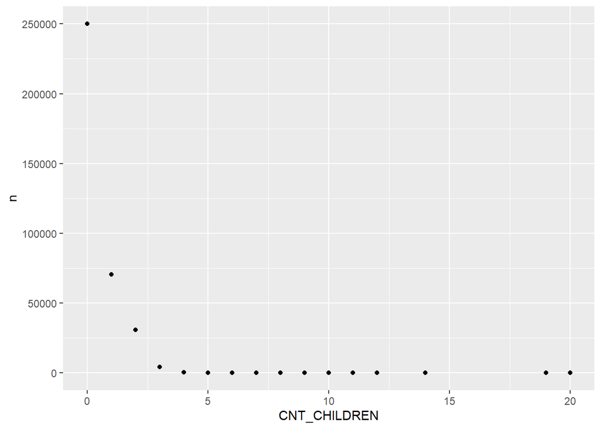

```r
#Scatterplots and tables

train_samp |> count(CNT_CHILDREN) |> group_by(n) |> ggplot(aes(x = CNT_CHILDREN, y = n)) + geom_point()
```

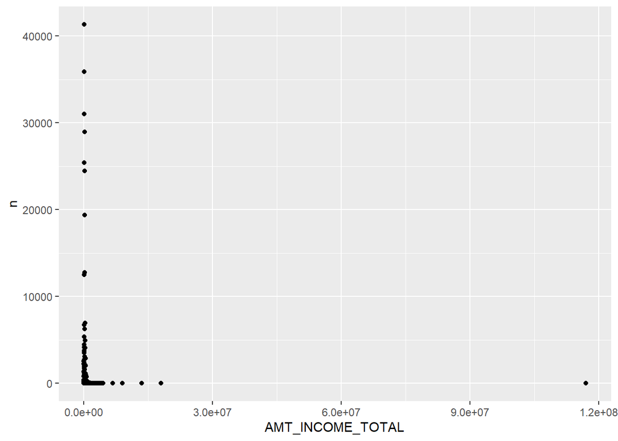

```r
train_samp |> count(AMT_INCOME_TOTAL) |> group_by(n) |> ggplot(aes(x = AMT_INCOME_TOTAL, y = n)) + geom_point()
```

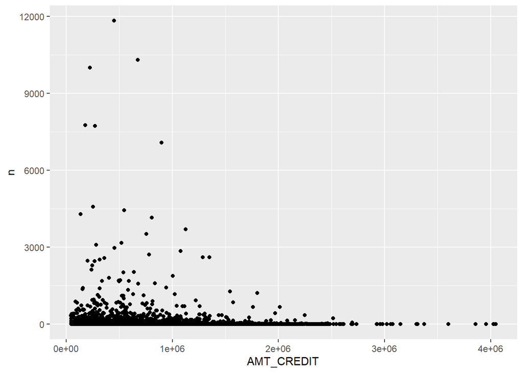

```r
train_samp |> count(AMT_CREDIT) |> group_by(n) |> ggplot(aes(x = AMT_CREDIT, y = n)) + geom_point()
```

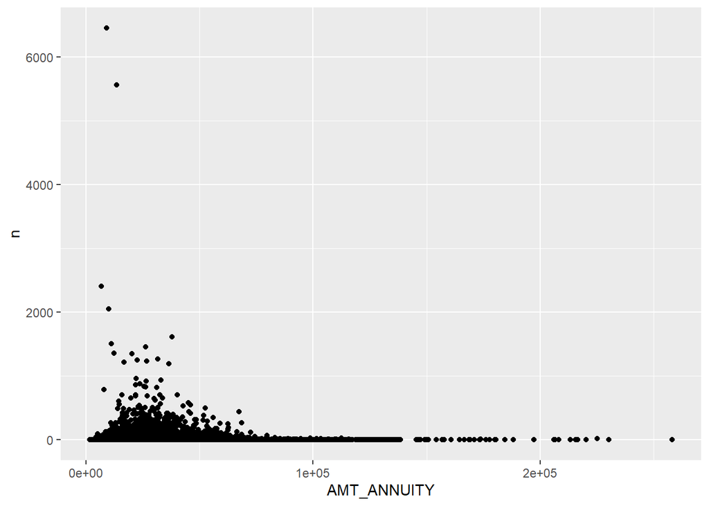

```r
train_samp |> count(AMT_ANNUITY) |> group_by(n) |> ggplot(aes(x = AMT_ANNUITY, y = n)) + geom_point()
```

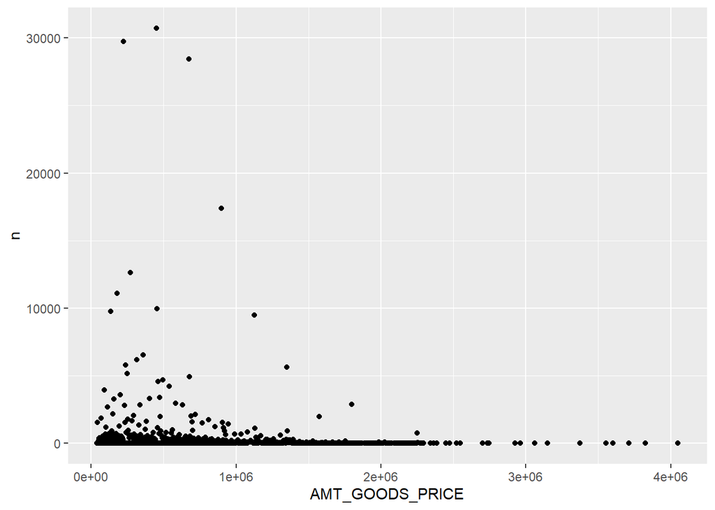

```r
train_samp |> count(AMT_GOODS_PRICE) |> group_by(n) |> ggplot(aes(x = AMT_GOODS_PRICE, y = n)) + geom_point()
```

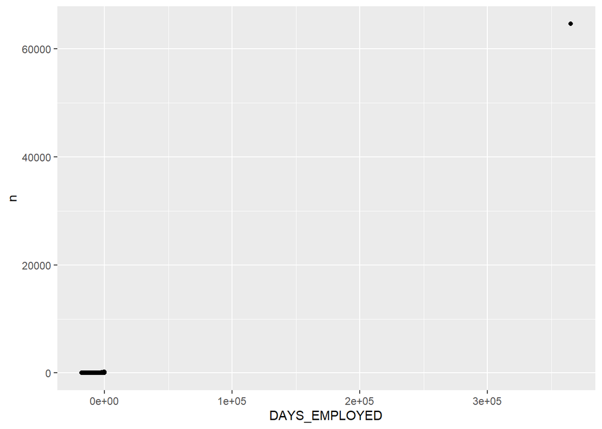

```r
train_samp |> count(DAYS_EMPLOYED) |> group_by(n) |> ggplot(aes(x = DAYS_EMPLOYED, y = n)) + geom_point()
```

```r
train_samp |> count(CNT_FAM_MEMBERS) |> group_by(n)
```

```
## # A tibble: 19 x 2
## # Groups:   n [13]
##    CNT_FAM_MEMBERS      n
##              <dbl>  <int>
##  1               1  78098
##  2               2 184411
##  3               3  60774
##  4               4  28387
##  5               5   3990
##  6               6    451
##  7               7     93
##  8               8     22
##  9               9      7
## 10              10      6
## 11              11      1
## 12              12      2
## 13              13      3
## 14              14      2
## 15              15      1
## 16              16      2
## 17              20      2
## 18              21      1
## 19              NA      2
```

```r
train_samp |> count(OBS_30_CNT_SOCIAL_CIRCLE) |> group_by(n)
```

```
## # A tibble: 37 x 2
## # Groups:   n [30]
##    OBS_30_CNT_SOCIAL_CIRCLE      n
##                       <dbl>  <int>
##  1                        0 189935
##  2                        1  56548
##  3                        2  34559
##  4                        3  23591
##  5                        4  16345
##  6                        5  11020
##  7                        6   7487
##  8                        7   5085
##  9                        8   3453
## 10                        9   2347
## # i 27 more rows
```

```r
train_samp |> count(OBS_60_CNT_SOCIAL_CIRCLE) |> group_by(n)
```

```
## # A tibble: 36 x 2
## # Groups:   n [31]
##    OBS_60_CNT_SOCIAL_CIRCLE      n
##                       <dbl>  <int>
##  1                        0 190806
##  2                        1  56611
##  3                        2  34501
##  4                        3  23477
##  5                        4  16145
##  6                        5  10904
##  7                        6   7379
##  8                        7   5021
##  9                        8   3376
## 10                        9   2293
## # i 26 more rows
```

```r
train_samp |> count(DEF_30_CNT_SOCIAL_CIRCLE) |> group_by(n)
```

```
## # A tibble: 11 x 2
## # Groups:   n [10]
##    DEF_30_CNT_SOCIAL_CIRCLE      n
##                       <dbl>  <int>
##  1                        0 314519
##  2                        1  32771
##  3                        2   6157
##  4                        3   1381
##  5                        4    293
##  6                        5     64
##  7                        6     14
##  8                        7      1
##  9                        8      1
## 10                       34      4
## 11                       NA   1050
```

```r
train_samp |> count(DEF_60_CNT_SOCIAL_CIRCLE) |> group_by(n)
```

```
## # A tibble: 10 x 2
## # Groups:   n [10]
##    DEF_60_CNT_SOCIAL_CIRCLE      n
##                       <dbl>  <int>
##  1                        0 325335
##  2                        1  25325
##  3                        2   3666
##  4                        3    695
##  5                        4    152
##  6                        5     24
##  7                        6      3
##  8                        7      1
##  9                       24      4
## 10                       NA   1050
```

```r
train_samp |> count(OCCUPATION_TYPE) |> group_by(n)
```

```
## # A tibble: 19 x 2
## # Groups:   n [19]
##    OCCUPATION_TYPE            n
##    <chr>                  <int>
##  1 Accountants            11441
##  2 Cleaning staff          5309
##  3 Cooking staff           6840
##  4 Core staff             31931
##  5 Drivers                21376
##  6 HR staff                 667
##  7 High skill tech staff  13234
##  8 IT staff                 607
##  9 Laborers               63841
## 10 Low-skill Laborers      2365
## 11 Managers               24945
## 12 Medicine staff          9853
## 13 Private service staff   3107
## 14 Realty agents            889
## 15 Sales staff            37174
## 16 Secretaries             1518
## 17 Security staff          7636
## 18 Waiters/barmen staff    1526
## 19 <NA>                  111996
```

There are obvious outliers in AMT_INCOME_TOTAL, AMT_CREDIT, DAYS_EMPLOYED, and AMT_GOODS_PRICE. Instead of filtering these, which will eliminate rows, we will use log transformations in the model to scale the column.

## Replacing Missing Numerical Values

Here we will replace missing values in the main data.

```r
# Replacing values with the median:


train_samp <- train_samp |>
mutate(AMT_GOODS_PRICE = replace_na(AMT_GOODS_PRICE, median(AMT_GOODS_PRICE, na.rm = T)), OWN_CAR_AGE = replace_na(OWN_CAR_AGE, median(OWN_CAR_AGE, na.rm = T)), EXT_SOURCE_1 = replace_na(EXT_SOURCE_1, median(EXT_SOURCE_1, na.rm = T)), EXT_SOURCE_2 = replace_na(EXT_SOURCE_2, median(EXT_SOURCE_2, na.rm = T)), EXT_SOURCE_3 = replace_na(EXT_SOURCE_3, median(EXT_SOURCE_3, na.rm = T)), OBS_30_CNT_SOCIAL_CIRCLE = replace_na(OBS_30_CNT_SOCIAL_CIRCLE, median(OBS_30_CNT_SOCIAL_CIRCLE, na.rm = T)), OBS_60_CNT_SOCIAL_CIRCLE = replace_na(OBS_60_CNT_SOCIAL_CIRCLE, median(OBS_60_CNT_SOCIAL_CIRCLE, na.rm = T)), DEF_30_CNT_SOCIAL_CIRCLE = replace_na(DEF_30_CNT_SOCIAL_CIRCLE, median(DEF_30_CNT_SOCIAL_CIRCLE, na.rm = T)), DEF_60_CNT_SOCIAL_CIRCLE = replace_na(DEF_60_CNT_SOCIAL_CIRCLE, median(DEF_60_CNT_SOCIAL_CIRCLE, na.rm = T)), AMT_REQ_CREDIT_BUREAU_HOUR = replace_na(AMT_REQ_CREDIT_BUREAU_HOUR, median(AMT_REQ_CREDIT_BUREAU_HOUR, na.rm = T)), AMT_REQ_CREDIT_BUREAU_DAY = replace_na(AMT_REQ_CREDIT_BUREAU_DAY, median(AMT_REQ_CREDIT_BUREAU_DAY, na.rm = T)), AMT_REQ_CREDIT_BUREAU_WEEK = replace_na(AMT_REQ_CREDIT_BUREAU_WEEK, median(AMT_REQ_CREDIT_BUREAU_WEEK, na.rm = T)), AMT_REQ_CREDIT_BUREAU_MON = replace_na(AMT_REQ_CREDIT_BUREAU_MON, median(AMT_REQ_CREDIT_BUREAU_MON, na.rm = T)), AMT_REQ_CREDIT_BUREAU_QRT = replace_na(AMT_REQ_CREDIT_BUREAU_QRT, median(AMT_REQ_CREDIT_BUREAU_QRT, na.rm = T)), AMT_REQ_CREDIT_BUREAU_YEAR = replace_na(AMT_REQ_CREDIT_BUREAU_YEAR, median(AMT_REQ_CREDIT_BUREAU_YEAR, na.rm = T)))

# Replacing missing values with the median for data on building where client lives. This data should exist for most, if not all people, so the median should be a sufficient estimate.

train_samp <- train_samp |>
mutate(APARTMENTS_AVG = replace_na(APARTMENTS_AVG, median(APARTMENTS_AVG, na.rm = T)), BASEMENTAREA_AVG = replace_na(BASEMENTAREA_AVG, median(BASEMENTAREA_AVG, na.rm = T)), YEARS_BEGINEXPLUATATION_AVG = replace_na(YEARS_BEGINEXPLUATATION_AVG, median(YEARS_BEGINEXPLUATATION_AVG, na.rm = T)), YEARS_BUILD_AVG = replace_na(YEARS_BUILD_AVG, median(YEARS_BUILD_AVG, na.rm = T)), COMMONAREA_AVG = replace_na(COMMONAREA_AVG, median(COMMONAREA_AVG, na.rm = T)), ENTRANCES_AVG = replace_na(ENTRANCES_AVG, median(ENTRANCES_AVG, na.rm = T)), FLOORSMAX_AVG = replace_na(FLOORSMAX_AVG, median(FLOORSMAX_AVG, na.rm = T)), FLOORSMIN_AVG = replace_na(FLOORSMIN_AVG, median(FLOORSMIN_AVG, na.rm = T)), LANDAREA_AVG = replace_na(LANDAREA_AVG, median(LANDAREA_AVG, na.rm = T)), LIVINGAPARTMENTS_AVG = replace_na(LIVINGAPARTMENTS_AVG, median(LIVINGAPARTMENTS_AVG, na.rm = T)), LIVINGAREA_AVG = replace_na(LIVINGAREA_AVG, median(LIVINGAREA_AVG, na.rm = T)), NONLIVINGAPARTMENTS_AVG = replace_na(NONLIVINGAPARTMENTS_AVG, median(NONLIVINGAPARTMENTS_AVG, na.rm = T)), NONLIVINGAREA_AVG = replace_na(NONLIVINGAREA_AVG, median(NONLIVINGAREA_AVG, na.rm = T)), APARTMENTS_MODE = replace_na(APARTMENTS_MODE, median(APARTMENTS_MODE, na.rm = T)), BASEMENTAREA_MODE = replace_na(BASEMENTAREA_MODE, median(BASEMENTAREA_MODE, na.rm = T)), YEARS_BEGINEXPLUATATION_MODE = replace_na(YEARS_BEGINEXPLUATATION_MODE, median(YEARS_BEGINEXPLUATATION_MODE, na.rm = T)), YEARS_BUILD_MODE = replace_na(YEARS_BUILD_MODE, median(YEARS_BUILD_MODE, na.rm = T)), FLOORSMAX_MODE = replace_na(FLOORSMAX_MODE, median(FLOORSMAX_MODE, na.rm = T)), FLOORSMIN_MODE = replace_na(FLOORSMIN_MODE, median(FLOORSMIN_MODE, na.rm = T)), LANDAREA_MODE = replace_na(LANDAREA_MODE, median(LANDAREA_MODE, na.rm = T)), LIVINGAPARTMENTS_MODE = replace_na(LIVINGAPARTMENTS_MODE, median(LIVINGAPARTMENTS_MODE, na.rm = T)), LIVINGAREA_MODE = replace_na(LIVINGAREA_MODE, median(LIVINGAREA_MODE, na.rm = T)), NONLIVINGAPARTMENTS_MODE = replace_na(NONLIVINGAPARTMENTS_MODE, median(NONLIVINGAPARTMENTS_MODE, na.rm = T)), NONLIVINGAREA_MODE = replace_na(NONLIVINGAREA_MODE, median(NONLIVINGAREA_MODE, na.rm = T)), APARTMENTS_MEDI = replace_na(APARTMENTS_MEDI, median(APARTMENTS_MEDI, na.rm = T)), BASEMENTAREA_MEDI = replace_na(BASEMENTAREA_MEDI, median(BASEMENTAREA_MEDI, na.rm = T)), YEARS_BEGINEXPLUATATION_MEDI = replace_na(YEARS_BEGINEXPLUATATION_MEDI, median(YEARS_BEGINEXPLUATATION_MEDI, na.rm = T)), YEARS_BUILD_MEDI = replace_na(YEARS_BUILD_MEDI, median(YEARS_BUILD_MEDI, na.rm = T)), COMMONAREA_MEDI = replace_na(COMMONAREA_MEDI, median(COMMONAREA_MEDI, na.rm = T)), ENTRANCES_MEDI = replace_na(ENTRANCES_MEDI, median(ENTRANCES_MEDI, na.rm = T)), FLOORSMAX_MEDI = replace_na(FLOORSMAX_MEDI, median(FLOORSMAX_MEDI, na.rm = T)), FLOORSMIN_MEDI = replace_na(FLOORSMIN_MEDI, median(FLOORSMIN_MEDI, na.rm = T)), LANDAREA_MEDI = replace_na(LANDAREA_MEDI, median(LANDAREA_MEDI, na.rm = T)), LIVINGAPARTMENTS_MEDI = replace_na(LIVINGAPARTMENTS_MEDI, median(LIVINGAPARTMENTS_MEDI, na.rm = T)), LIVINGAREA_MEDI = replace_na(LIVINGAREA_MEDI, median(LIVINGAREA_MEDI, na.rm = T)), NONLIVINGAPARTMENTS_MEDI = replace_na(NONLIVINGAPARTMENTS_MEDI, median(NONLIVINGAPARTMENTS_MEDI, na.rm = T)), NONLIVINGAREA_MEDI = replace_na(NONLIVINGAREA_MEDI, median(NONLIVINGAREA_MEDI, na.rm = T)), TOTALAREA_MODE = replace_na(TOTALAREA_MODE, median(TOTALAREA_MODE, na.rm = T)), ENTRANCES_MODE = replace_na(ENTRANCES_MODE, median(ENTRANCES_MODE, na.rm = T)))

#Replacing values with zero: Many people wouldn't live in a building with an elevator or a common area, so it would make sense to replace these missing values with zero. That said, the median would likely be close to zero anyway.

train_samp <- train_samp |>
mutate(ELEVATORS_AVG = replace_na(data = ELEVATORS_AVG, replace = 0), COMMONAREA_MODE = replace_na(data = COMMONAREA_MODE, replace = 0), ELEVATORS_MODE = replace_na(data = ELEVATORS_MODE, replace = 0))
```

## Replacing Other Missing Values

```r
#counting the missing values

train_samp |> count(FONDKAPREMONT_MODE) |> group_by(n) #Will replace NAs with 'not specified.'
```

```
## # A tibble: 5 x 2
## # Groups:   n [5]
##   FONDKAPREMONT_MODE         n
##   <chr>                  <int>
## 1 not specified           6600
## 2 org spec account        6539
## 3 reg oper account       85954
## 4 reg oper spec account  14070
## 5 <NA>                  243092
```

```r
train_samp |> count(HOUSETYPE_MODE) |> group_by(n) #Will replace NAs with 'block of flats'
```

```
## # A tibble: 4 x 2
## # Groups:   n [4]
##   HOUSETYPE_MODE        n
##   <chr>             <int>
## 1 block of flats   175162
## 2 specific housing   1761
## 3 terraced house     1416
## 4 <NA>             177916
```

```r
train_samp |> count(WALLSMATERIAL_MODE) |> group_by(n) #As more data is missing than is present, it may be wise not to replace missing values.
```

```
## # A tibble: 8 x 2
## # Groups:   n [8]
##   WALLSMATERIAL_MODE      n
##   <chr>               <int>
## 1 Block               10681
## 2 Mixed                2649
## 3 Monolithic           2068
## 4 Others               1909
## 5 Panel               77309
## 6 Stone, brick        75249
## 7 Wooden               6156
## 8 <NA>               180234
```

```r
train_samp |> count(EMERGENCYSTATE_MODE) |> group_by(n) #Will replace NAs with 'No'
```

```
## # A tibble: 3 x 2
## # Groups:   n [3]
##   EMERGENCYSTATE_MODE      n
##   <chr>                <int>
## 1 No                  185607
## 2 Yes                   2684
## 3 <NA>                167964
```

```r
train_samp |> count(OCCUPATION_TYPE) |> group_by(n) #Will replace NAs with 'other'
```

```
## # A tibble: 19 x 2
## # Groups:   n [19]
##    OCCUPATION_TYPE            n
##    <chr>                  <int>
##  1 Accountants            11441
##  2 Cleaning staff          5309
##  3 Cooking staff           6840
##  4 Core staff             31931
##  5 Drivers                21376
##  6 HR staff                 667
##  7 High skill tech staff  13234
##  8 IT staff                 607
##  9 Laborers               63841
## 10 Low-skill Laborers      2365
## 11 Managers               24945
## 12 Medicine staff          9853
## 13 Private service staff   3107
## 14 Realty agents            889
## 15 Sales staff            37174
## 16 Secretaries             1518
## 17 Security staff          7636
## 18 Waiters/barmen staff    1526
## 19 <NA>                  111996
```

```r
#Here we will replace missing categorical values and other not-so-obvious values.

train_samp <- train_samp |>
mutate(FONDKAPREMONT_MODE = replace_na(data = FONDKAPREMONT_MODE, replace = "not specified"), HOUSETYPE_MODE = replace_na(data = HOUSETYPE_MODE, replace = "block of flats"), EMERGENCYSTATE_MODE = replace_na(data = EMERGENCYSTATE_MODE, replace = "No"))

train_samp <- train_samp |>
mutate(ELEVATORS_MEDI = replace_na(data = ELEVATORS_MEDI, replace = 0), DAYS_LAST_PHONE_CHANGE = replace_na(data = DAYS_LAST_PHONE_CHANGE, replace = 0), AMT_ANNUITY = replace_na(AMT_ANNUITY, median(AMT_ANNUITY, na.rm = T)), ELEVATORS_MODE = replace_na(data = ELEVATORS_MODE, replace = 0), CNT_FAM_MEMBERS = replace_na(data = CNT_FAM_MEMBERS, replace = 0))

train_samp <- train_samp |>
  mutate(OCCUPATION_TYPE = replace_na(OCCUPATION_TYPE, "other"), NAME_TYPE_SUITE = replace_na(NAME_TYPE_SUITE, "other"), WALLSMATERIAL_MODE = replace_na(WALLSMATERIAL_MODE, "other"))

# It should be noted that for the value DAYS_EMPLOYED, the positive values are not possible:

train_samp[train_samp$DAYS_EMPLOYED < 0, "DAYS_EMPLOYED"] <- 0
```

## Removing Zero-Variance and Highly Correlated Variables:

Here we will remove variables that are relatively constant and unlikely to affect the target variable, along with variables that fluxuate with other variables.

```r
# Separate numeric and non-numeric columns
numeric_vars <- train_samp[sapply(train_samp, is.numeric)]
non_numeric_vars <- train_samp[sapply(train_samp, Negate(is.numeric))]

# Remove zero variance columns - can also try nearZeroVar()
numeric_vars <- numeric_vars[, apply(numeric_vars, 2, var, na.rm = TRUE) > 0, drop = FALSE]

# Compute the correlation matrix for numeric variables
cor_matrix <- cor(numeric_vars)

# Find highly correlated variables (absolute correlation > 0.9)
highly_correlated <- findCorrelation(cor_matrix, cutoff = 0.9)

# Remove highly correlated numeric variables
filtered_numeric_vars <- numeric_vars[, -highly_correlated, drop = FALSE]

# Combine back with non-numeric variables
train_samp2 <- cbind(non_numeric_vars, filtered_numeric_vars)
```

# Characters to Factors and Reviewing Changes

In this section we change character variables to factors so the models can operate more efficiently.

```r
train_samp2 <- train_samp2 |>
  mutate_if(is.character, function(x) factor(x))#factoring data

ncol(train_samp2)
```

```
## [1] 90
```

```r
sum(is.na(train_samp2))
```

```
## [1] 0
```

```r
sum(is.character(train_samp2))
```

```
## [1] 0
```

# New Data Sources:

Because Home Credit is examing data unreleated to credit score, we will analyze additional files to find relevant predictors and join them to the main file on the variable SK_ID_CURR.

## Bureau

```r
#Loading and examining bureau data

bureau <- read_csv("bureau.csv")

#Replacing missing values with 0:

bureau <- bureau |>
mutate(DAYS_CREDIT_ENDDATE = replace_na(data = DAYS_CREDIT_ENDDATE, replace = 0), AMT_CREDIT_MAX_OVERDUE = replace_na(data = AMT_CREDIT_MAX_OVERDUE, replace = 0), AMT_CREDIT_SUM_DEBT = replace_na(data = AMT_CREDIT_SUM_DEBT, replace = 0), AMT_CREDIT_SUM_LIMIT = replace_na(data = AMT_CREDIT_SUM_LIMIT, replace = 0), AMT_ANNUITY = replace_na(data = AMT_ANNUITY, replace = 0))

#DAYS_ENDDATE_FACT is missing information, but it applies only to closed credit. May be best to ignore this column.

#Selecting columns to join with main data:
bureau_join <- bureau |> group_by(SK_ID_CURR) |> summarise(Total_CREDIT_DAY_OVERDUE = sum(CREDIT_DAY_OVERDUE), Total_AMT_CREDIT_SUM_DEBT = sum(AMT_CREDIT_SUM_DEBT), Total_AMT_CREDIT_SUM_OVERDUE = sum(AMT_CREDIT_SUM_OVERDUE))
```

## Bureau_Balance

```r
#loading and examining bureau balance

bureau_balance <- read_csv("bureau_balance.csv", n_max = 20000)

#No missing values.
```

## POS_CASH_balance

```r
#loading and reviewing pos cash balance

POS_CASH_balance <- read_csv("POS_CASH_balance.csv")

#CNT_INSTALMENT missing values could indicate that they didn't have previous credit. Can replace with zeros:
POS_CASH_balance <- POS_CASH_balance |>
mutate(CNT_INSTALMENT = replace_na(data = CNT_INSTALMENT, replace = 0), CNT_INSTALMENT_FUTURE = replace_na(data = CNT_INSTALMENT_FUTURE, replace = 0))

#prepping data to merge with our training data

POS_CASH_balance_join <- POS_CASH_balance |> group_by(SK_ID_CURR) |> summarise(Total_CNT_INSTALMENT_FUTURE = sum(CNT_INSTALMENT_FUTURE), Total_SK_DPD = sum(SK_DPD))
```

## credit_card_balance

```r
#loading and reviewing credit card balance

credit_card_balance <- read_csv("credit_card_balance.csv", n_max = 20000)

#Replacing missing values with zero. As most of these are transactions the median may also be appropriate?
credit_card_balance <- credit_card_balance |>
mutate(AMT_DRAWINGS_ATM_CURRENT = replace_na(data = AMT_DRAWINGS_ATM_CURRENT, replace = 0), AMT_DRAWINGS_OTHER_CURRENT = replace_na(data = AMT_DRAWINGS_OTHER_CURRENT, replace = 0), AMT_DRAWINGS_POS_CURRENT = replace_na(data = AMT_DRAWINGS_POS_CURRENT, replace = 0), AMT_INST_MIN_REGULARITY = replace_na(data = AMT_INST_MIN_REGULARITY, replace = 0), AMT_PAYMENT_CURRENT = replace_na(data = AMT_PAYMENT_CURRENT, replace = 0), CNT_DRAWINGS_ATM_CURRENT = replace_na(data = CNT_DRAWINGS_ATM_CURRENT, replace = 0), CNT_DRAWINGS_OTHER_CURRENT = replace_na(data = CNT_DRAWINGS_OTHER_CURRENT, replace = 0), CNT_DRAWINGS_POS_CURRENT = replace_na(data = CNT_DRAWINGS_POS_CURRENT, replace = 0), CNT_INSTALMENT_MATURE_CUM = replace_na(data = CNT_INSTALMENT_MATURE_CUM, replace = 0))

#prepping data to merge with our training data

credit_card_balance_join <- credit_card_balance |> group_by(SK_ID_CURR) |> summarise(Total_AMT_DRAWINGS_ATM_CURRENT = sum(AMT_DRAWINGS_ATM_CURRENT), total_AMT_DRAWINGS_OTHER_CURRENT = sum(AMT_DRAWINGS_OTHER_CURRENT), total_AMT_DRAWINGS_POS_CURRENT = sum(AMT_DRAWINGS_POS_CURRENT), Total_AMT_PAYMENT_CURRENT = sum(AMT_PAYMENT_CURRENT), total_CNT_DRAWINGS_ATM_CURRENT = sum(CNT_DRAWINGS_ATM_CURRENT), Total_CNT_DRAWINGS_OTHER_CURRENT = sum(CNT_DRAWINGS_OTHER_CURRENT), total_CNT_DRAWINGS_POS_CURRENT = sum(CNT_DRAWINGS_POS_CURRENT), Total_CNT_INSTALMENT_MATURE_CUM = sum(CNT_INSTALMENT_MATURE_CUM))
```

## previous_application

```r
#loading and reviewing previous application.

previous_application <- read_csv("previous_application.csv")

#Replacing missing values with zero. As most of these are transactions the median may also be appropriate?
previous_application <- previous_application |>
mutate(AMT_ANNUITY = replace_na(data = AMT_ANNUITY, replace = 0), AMT_APPLICATION = replace_na(data = AMT_APPLICATION, replace = 0), AMT_CREDIT = replace_na(data = AMT_CREDIT, replace = 0), AMT_DOWN_PAYMENT = replace_na(data = AMT_DOWN_PAYMENT, replace = 0), AMT_GOODS_PRICE = replace_na(data = AMT_GOODS_PRICE, replace = 0), RATE_DOWN_PAYMENT = replace_na(data = RATE_DOWN_PAYMENT, replace = 0), RATE_INTEREST_PRIMARY = replace_na(data = RATE_INTEREST_PRIMARY, replace = 0), RATE_INTEREST_PRIVILEGED = replace_na(data = RATE_INTEREST_PRIVILEGED, replace = 0), CNT_PAYMENT = replace_na(data = CNT_PAYMENT, replace = 0), NFLAG_INSURED_ON_APPROVAL = replace_na(data = NFLAG_INSURED_ON_APPROVAL, replace = 0))

#Replacing missing values in the NAME_TYPE_SUITE
previous_application <- previous_application |>
mutate(NAME_TYPE_SUITE = replace_na(data = NAME_TYPE_SUITE, replace = "Unaccompanied"))

#These attributes can either be removed or replaced with the median: DAYS_FIRST_DRAWING, DAYS_FIRST_DUE, DAYS_LAST_DUE_1ST_VERSION, DAYS_LAST_DUE, DAYS_TERMINATION

#prepping data to merge with our training data

previous_application_join <- previous_application |> group_by(SK_ID_CURR) |> summarise(Total_AMT_ANNUITY = sum(AMT_ANNUITY), Total_AMT_APPLICATION = sum(AMT_APPLICATION), total_AMT_CREDIT = sum(AMT_CREDIT), total_AMT_DOWN_PAYMENT = sum(AMT_DOWN_PAYMENT), total_AMT_GOODS_PRICE = sum(AMT_GOODS_PRICE), total_RATE_DOWN_PAYMENT = sum(RATE_DOWN_PAYMENT), avg_RATE_INTEREST_PRIMARY = mean(RATE_INTEREST_PRIMARY), total_CNT_PAYMENT
 = sum(CNT_PAYMENT))
```

## installments_payments

```r
#loading and reviewing installments payments

installments_payments <- read_csv(file = "installments_payments.csv")


#The information most important in here is the difference between due date and payment date. Rather than changing the format, we can just find the difference. We can do the same for prescribed payments vs actual payments:
installments_payments <- installments_payments |> mutate(days_late = DAYS_INSTALMENT - DAYS_ENTRY_PAYMENT, payment_diff = AMT_INSTALMENT - AMT_PAYMENT)

#prepping data to merge with our training data

install_payments <- installments_payments |> group_by(SK_ID_CURR) |> summarise(avg_days_late = mean(days_late), avg_payment_diff = mean(payment_diff))
```

# Merging Data Sources

As a complete data file would be massive, only a selected few data sources will be combined based on likelihood of influence.

```r
#merging only a select number of sources as to not crash the system.

merge(x = train_samp2, y = previous_application_join, by = "SK_ID_CURR", all.x = TRUE) -> df
merge(x = df, y = POS_CASH_balance_join, by = "SK_ID_CURR", all.x = TRUE) -> df
merge(x = df, y = install_payments, by = "SK_ID_CURR", all.x = TRUE) -> df
merge(x = df, y = bureau_join, by = "SK_ID_CURR", all.x = TRUE) -> df
```

Missing data here implies there are no records - will be replaced with zero:

## Replacing missing values in final data set

```r
#replacing missing values with zero as missing data is most likely due to missing records.

df <- df|>
mutate(
avg_RATE_INTEREST_PRIMARY = replace_na(data = avg_RATE_INTEREST_PRIMARY, replace = 0),
total_CNT_PAYMENT = replace_na(data = total_CNT_PAYMENT, replace = 0),
Total_CNT_INSTALMENT_FUTURE = replace_na(data = Total_CNT_INSTALMENT_FUTURE, replace = 0),
Total_SK_DPD = replace_na(data = Total_SK_DPD, replace = 0),
avg_days_late = replace_na(data = avg_days_late, replace = 0),
avg_payment_diff = replace_na(data = avg_payment_diff, replace = 0),
Total_AMT_ANNUITY = replace_na(data = Total_AMT_ANNUITY, replace = 0),
Total_AMT_APPLICATION = replace_na(data = Total_AMT_APPLICATION, replace = 0),
total_AMT_CREDIT = replace_na(data = total_AMT_CREDIT, replace = 0),
total_AMT_DOWN_PAYMENT = replace_na(data = total_AMT_DOWN_PAYMENT, replace = 0),
total_AMT_GOODS_PRICE = replace_na(data = total_AMT_GOODS_PRICE, replace = 0),
total_RATE_DOWN_PAYMENT = replace_na(data = total_RATE_DOWN_PAYMENT, replace = 0),
Total_CREDIT_DAY_OVERDUE = replace_na(data = Total_CREDIT_DAY_OVERDUE, replace = 0),
Total_AMT_CREDIT_SUM_DEBT = replace_na(data = Total_AMT_CREDIT_SUM_DEBT, replace = 0),
Total_AMT_CREDIT_SUM_OVERDUE = replace_na(data = Total_AMT_CREDIT_SUM_OVERDUE, replace = 0)
)
```

## Checking again for Zero-Variance and Highly Correlated Variables:

```r
# Separate numeric and non-numeric columns
numeric_vars <- df[sapply(df, is.numeric)]
non_numeric_vars <- df[sapply(df, Negate(is.numeric))]

# Remove zero variance columns - can also try nearZeroVar()
numeric_vars <- numeric_vars[, apply(numeric_vars, 2, var, na.rm = TRUE) > 0, drop = FALSE]

# Compute the correlation matrix for numeric variables
cor_matrix <- cor(numeric_vars)

# Find highly correlated variables (absolute correlation > 0.9)
highly_correlated <- findCorrelation(cor_matrix, cutoff = 0.9)

# Remove highly correlated numeric variables
filtered_numeric_vars <- numeric_vars[, -highly_correlated, drop = FALSE]

# Combine back with non-numeric variables
df2 <- cbind(non_numeric_vars, filtered_numeric_vars)
```

## Confirming our changes

```r
ncol(df2)
```

```
## [1] 102
```

```r
nrow(df2)
```

```
## [1] 356255
```

```r
sum(is.na(df2))
```

```
## [1] 0
```

```r
sum(is.character(df2))
```

```
## [1] 0
```

# Separating Back into Test and Train Sets

Here we undo our initial merge.

```r
#put selected data frames into list
df_test <- df2 |> filter(TARGET == 2)
df_train <- df2 |> filter(TARGET != 2)

#Changing TARGET variable into a factor

df_test <- df_test |>
  mutate(TARGET = factor(TARGET))#factoring data

df_train <- df_train |>
   mutate(TARGET = factor(TARGET))#factoring data
```

# Sampling Test Data

Here we will split the train data into two parts - 70% of the data will be used to train our models and 30% will be used to validate them.

```r
# Randomly sample 70% of the rows in an object called index.
set.seed(124)
index <- sample(x = 1:nrow(df_train), size = nrow(df_train)*.7, replace = F)

# Check
head(index) # These are the 70% randomly sampled row numbers
```

```
## [1]  26791  91547 281304  83873 252334  39554
```

```r
# Subset train using index to create a 70% train_fold
train_fold <- df_train[index, ]

# Subset the remaining rows not included in index to create a 30% validation fold
validation_fold <- df_train[-index, ]
```

# Tree Model

Building tree models to find most influential predictors.

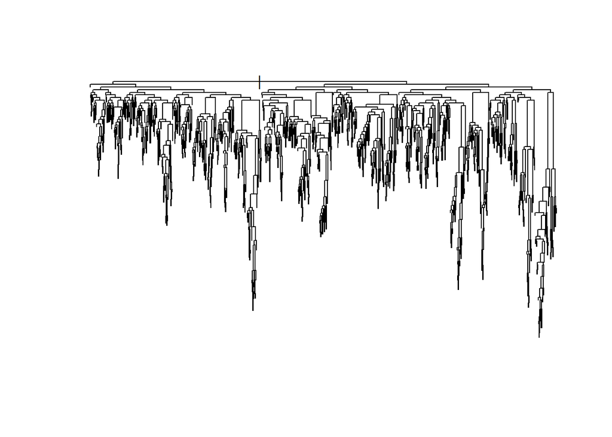

```r
#building the first tree model with a low info-gain threshold.
tree_1 <- rpart(TARGET ~. -SK_ID_CURR, train_fold, method="class",control =rpart.control(minsplit =1,minbucket=1, cp=0.0001))

plot(tree_1)
```

This model is very complex. We will increase the information gain threshold to make the model more readable.

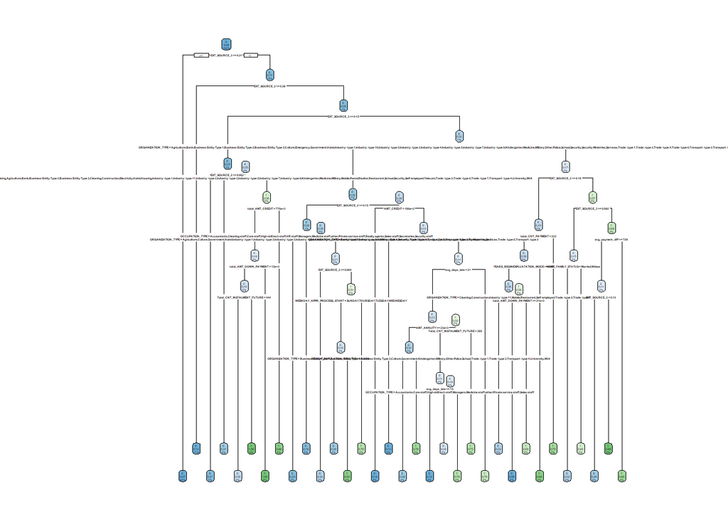

```r
#building a second, less-complex tree model.
tree_2 <- rpart(TARGET ~. -SK_ID_CURR, train_fold, method="class",control =rpart.control(minsplit =1,minbucket=1, cp=0.0003))

rpart.plot(tree_2)
```

# Predictions

Here we will generate predictions based on the tree models.

```r
#generating predictions for train sets
tree_1_train_predictions <- predict(tree_1,train_fold)
tree_2_train_predictions <- predict(tree_2,train_fold)
```

```r
#generating predictions for test sets
tree_1_test_predictions <- predict(tree_1,validation_fold)
tree_2_test_predictions <- predict(tree_2,validation_fold)
```

## Confusion Matrices

These help us determine the accuracy of the tree models on the train and validation data.

```r
#confusion matrices for train data
mmetric(train_fold$TARGET, tree_1_train_predictions, metric="CONF")
```

```
## $res
## NULL
##
## $conf
##       pred
## target      0      1
##      0 197669    261
##      1  13648   3679
##
## $roc
## NULL
##
## $lift
## NULL
```

```r
mmetric(validation_fold$TARGET, tree_1_test_predictions, metric="CONF")
```

```
## $res
## NULL
##
## $conf
##       pred
## target     0     1
##      0 83544  1212
##      1  7037   461
##
## $roc
## NULL
##
## $lift
## NULL
```

```r
mmetric(train_fold$TARGET, tree_2_train_predictions, metric="CONF")
```

```
## $res
## NULL
##
## $conf
##       pred
## target      0      1
##      0 197810    120
##      1  16979    348
##
## $roc
## NULL
##
## $lift
## NULL
```

```r
mmetric(validation_fold$TARGET, tree_2_test_predictions, metric="CONF")
```

```
## $res
## NULL
##
## $conf
##       pred
## target     0     1
##      0 84644   112
##      1  7408    90
##
## $roc
## NULL
##
## $lift
## NULL
```

```r
# generating an accuracy chart for tree 1

mmetric(train_fold$TARGET, tree_1_train_predictions, metric=c("F1","ACC","PRECISION","RECALL"))
```

```
##        F11        F12        ACC PRECISION1 PRECISION2
##   96.60132   34.59820   93.53842   93.54146   93.37563
```

```r
mmetric(validation_fold$TARGET, tree_1_test_predictions, metric=c("F1","ACC","PRECISION","RECALL"))
```

```
##        F11        F12        ACC PRECISION1 PRECISION2
##   95.29535   10.05343   91.05838   92.23126   27.55529
```

The first tree model has 93.5% accuracy on the train data and 91% accuracy on the validation data.

```r
# generating an accuracy chart for tree 2

mmetric(train_fold$TARGET, tree_2_train_predictions, metric=c("F1","ACC","PRECISION","RECALL"))
```

```
##        F11        F12        ACC PRECISION1 PRECISION2
##  95.856987   3.911211  92.056472  92.095033  74.358974
```

```r
mmetric(validation_fold$TARGET, tree_2_test_predictions, metric=c("F1","ACC","PRECISION","RECALL"))
```

```
##        F11        F12        ACC PRECISION1 PRECISION2
##  95.746799   2.337662  91.848592  91.952375  44.554455
```

The second model has a higher threshold of information gain for each mode and is thus not as complex as the first model. It only has 92% accuracy on the train data compared to 93.5% for the first model, but it may be a better model overall. The first model may have overfit the train data as the second model performs better with the validation data (91.8% to 91%) We’ll use these predictors in the second tree model for the logistical model.

##Model Features

This is a list of the most important features of the second tree model.

```r
#Finding the most important features of the tree model, as the graph is hard to interpret and the tree diagram is very long.

tree_2$variable.importance
```

```
##                 EXT_SOURCE_3                 EXT_SOURCE_2
##                  618.4589749                  257.9819010
##            ORGANIZATION_TYPE              OCCUPATION_TYPE
##                   69.1454189                   18.9100474
##                avg_days_late                   AMT_CREDIT
##                   13.9113958                   13.8545633
##                  AMT_ANNUITY  Total_CNT_INSTALMENT_FUTURE
##                   13.2746774                   13.1515521
##             total_AMT_CREDIT     Total_CREDIT_DAY_OVERDUE
##                   12.9273882                   11.9645353
## Total_AMT_CREDIT_SUM_OVERDUE            total_CNT_PAYMENT
##                   11.7672626                   11.1931981
##       total_AMT_DOWN_PAYMENT             avg_payment_diff
##                    9.5492567                    7.7454748
##   WEEKDAY_APPR_PROCESS_START      total_RATE_DOWN_PAYMENT
##                    6.8473800                    6.4942000
##           NAME_FAMILY_STATUS   REGION_POPULATION_RELATIVE
##                    6.0190703                    5.7020105
##             AMT_INCOME_TOTAL YEARS_BEGINEXPLUATATION_MODE
##                    4.6497162                    4.0252236
##    Total_AMT_CREDIT_SUM_DEBT            DAYS_REGISTRATION
##                    3.1979237                    2.7075127
##              CNT_FAM_MEMBERS              LIVINGAREA_MODE
##                    2.3825487                    2.2641645
##              APARTMENTS_MODE                   DAYS_BIRTH
##                    1.9931781                    1.9903341
##            NAME_HOUSING_TYPE                 Total_SK_DPD
##                    1.8880477                    1.6558608
##   AMT_REQ_CREDIT_BUREAU_YEAR               FLOORSMAX_MODE
##                    1.5892095                    1.5708898
##               TOTALAREA_MODE             YEARS_BUILD_MODE
##                    1.5059733                    1.4722171
##                  CODE_GENDER               ELEVATORS_MODE
##                    1.3981412                    1.1779391
##           NONLIVINGAREA_MODE     NONLIVINGAPARTMENTS_MODE
##                    1.1712068                    1.0904285
##           WALLSMATERIAL_MODE                   FLAG_PHONE
##                    0.9673877                    0.8686229
##       DAYS_LAST_PHONE_CHANGE          NAME_EDUCATION_TYPE
##                    0.7721092                    0.7421022
##              NAME_TYPE_SUITE             NAME_INCOME_TYPE
##                    0.6907376                    0.5395504
##            BASEMENTAREA_MODE                 CNT_CHILDREN
##                    0.5334091                    0.5083074
##                 EXT_SOURCE_1    avg_RATE_INTEREST_PRIMARY
##                    0.4926611                    0.2919421
##      HOUR_APPR_PROCESS_START             FLAG_DOCUMENT_11
##                    0.2599106                    0.2367625
##        LIVINGAPARTMENTS_MODE              DAYS_ID_PUBLISH
##                    0.2367625                    0.2010509
##                   FLAG_EMAIL               FLOORSMIN_MODE
##                    0.1847790                    0.1743797
##     OBS_60_CNT_SOCIAL_CIRCLE               ENTRANCES_MODE
##                    0.1061874                    0.0601363
```

# Logistical Model

```r
#building the log model based on the tree_2 predictors
reg_keg <- glm(TARGET ~ EXT_SOURCE_3 + EXT_SOURCE_2 + ORGANIZATION_TYPE + OCCUPATION_TYPE + avg_days_late + log(AMT_CREDIT) + AMT_ANNUITY + Total_CNT_INSTALMENT_FUTURE + total_AMT_CREDIT + Total_CREDIT_DAY_OVERDUE + Total_AMT_CREDIT_SUM_OVERDUE + total_CNT_PAYMENT + total_AMT_DOWN_PAYMENT + avg_payment_diff + WEEKDAY_APPR_PROCESS_START + total_RATE_DOWN_PAYMENT + NAME_FAMILY_STATUS + REGION_POPULATION_RELATIVE + log(AMT_INCOME_TOTAL) + YEARS_BEGINEXPLUATATION_MODE + Total_AMT_CREDIT_SUM_DEBT + DAYS_REGISTRATION + CNT_FAM_MEMBERS + LIVINGAREA_MODE*APARTMENTS_MODE + DAYS_BIRTH + NAME_HOUSING_TYPE + Total_SK_DPD + AMT_REQ_CREDIT_BUREAU_YEAR + FLOORSMAX_MODE + TOTALAREA_MODE + YEARS_BUILD_MODE + CODE_GENDER + ELEVATORS_MODE + NONLIVINGAREA_MODE*NONLIVINGAPARTMENTS_MODE -SK_ID_CURR, family = "binomial", data = train_fold)

summary(reg_keg, digits=2)
```

```
##
## Call:
## glm(formula = TARGET ~ EXT_SOURCE_3 + EXT_SOURCE_2 + ORGANIZATION_TYPE +
##     OCCUPATION_TYPE + avg_days_late + log(AMT_CREDIT) + AMT_ANNUITY +
##     Total_CNT_INSTALMENT_FUTURE + total_AMT_CREDIT + Total_CREDIT_DAY_OVERDUE +
##     Total_AMT_CREDIT_SUM_OVERDUE + total_CNT_PAYMENT + total_AMT_DOWN_PAYMENT +
##     avg_payment_diff + WEEKDAY_APPR_PROCESS_START + total_RATE_DOWN_PAYMENT +
##     NAME_FAMILY_STATUS + REGION_POPULATION_RELATIVE + log(AMT_INCOME_TOTAL) +
##     YEARS_BEGINEXPLUATATION_MODE + Total_AMT_CREDIT_SUM_DEBT +
##     DAYS_REGISTRATION + CNT_FAM_MEMBERS + LIVINGAREA_MODE * APARTMENTS_MODE +
##     DAYS_BIRTH + NAME_HOUSING_TYPE + Total_SK_DPD + AMT_REQ_CREDIT_BUREAU_YEAR +
##     FLOORSMAX_MODE + TOTALAREA_MODE + YEARS_BUILD_MODE + CODE_GENDER +
##     ELEVATORS_MODE + NONLIVINGAREA_MODE * NONLIVINGAPARTMENTS_MODE -
##     SK_ID_CURR, family = "binomial", data = train_fold)
##
## Coefficients:
##                                               Estimate Std. Error z value
## (Intercept)                                  1.786e+00  4.711e-01   3.790
## EXT_SOURCE_3                                -2.655e+00  4.628e-02 -57.379
## EXT_SOURCE_2                                -2.263e+00  4.092e-02 -55.300
## ORGANIZATION_TYPEAgriculture                 4.222e-02  2.323e-01   0.182
## ORGANIZATION_TYPEBank                       -3.641e-01  2.416e-01  -1.507
## ORGANIZATION_TYPEBusiness Entity Type 1     -1.622e-01  2.255e-01  -0.719
## ORGANIZATION_TYPEBusiness Entity Type 2     -1.097e-01  2.220e-01  -0.494
## ORGANIZATION_TYPEBusiness Entity Type 3      7.257e-03  2.183e-01   0.033
## ORGANIZATION_TYPECleaning                    2.231e-02  3.321e-01   0.067
## ORGANIZATION_TYPEConstruction                2.051e-01  2.229e-01   0.920
## ORGANIZATION_TYPECulture                    -2.102e-01  3.486e-01  -0.603
## ORGANIZATION_TYPEElectricity                -3.392e-01  2.696e-01  -1.258
## ORGANIZATION_TYPEEmergency                  -2.907e-01  2.944e-01  -0.987
## ORGANIZATION_TYPEGovernment                 -1.797e-01  2.228e-01  -0.806
## ORGANIZATION_TYPEHotel                      -3.998e-01  2.762e-01  -1.447
## ORGANIZATION_TYPEHousing                    -1.650e-01  2.340e-01  -0.705
## ORGANIZATION_TYPEIndustry: type 1            8.681e-02  2.498e-01   0.348
## ORGANIZATION_TYPEIndustry: type 10          -6.537e-01  5.818e-01  -1.124
## ORGANIZATION_TYPEIndustry: type 11          -9.926e-02  2.338e-01  -0.425
## ORGANIZATION_TYPEIndustry: type 12          -6.079e-01  3.822e-01  -1.590
## ORGANIZATION_TYPEIndustry: type 13          -1.123e-01  4.995e-01  -0.225
## ORGANIZATION_TYPEIndustry: type 2           -4.254e-01  3.154e-01  -1.349
## ORGANIZATION_TYPEIndustry: type 3           -4.263e-02  2.295e-01  -0.186
```

[output cut: 225 more lines]

```
## ELEVATORS_MODE                              0.155764
## NONLIVINGAREA_MODE                          0.193209
## NONLIVINGAPARTMENTS_MODE                    0.878995
## LIVINGAREA_MODE:APARTMENTS_MODE             0.057828 .
## NONLIVINGAREA_MODE:NONLIVINGAPARTMENTS_MODE 0.293096
## ---
## Signif. codes:  0 '***' 0.001 '**' 0.01 '*' 0.05 '.' 0.1 ' ' 1
##
## (Dispersion parameter for binomial family taken to be 1)
##
##     Null deviance: 120533  on 215256  degrees of freedom
## Residual deviance: 108617  on 215131  degrees of freedom
## AIC: 108869
##
## Number of Fisher Scoring iterations: 9
```

## Validation

```r
#generating predictions for train sets
glm_1_train_predictions <- predict(reg_keg,train_fold)


#generating predictions for test sets
glm_1_test_predictions <- predict(reg_keg,validation_fold)
```

```r
# generating an accuracy chart for tree 1

mmetric(train_fold$TARGET, glm_1_train_predictions, metric=c("F1","ACC","PRECISION","RECALL"))
```

```
##        F11        F12        ACC PRECISION1 PRECISION2
## 95.8059832  0.1498214 91.9500876 91.9555824 48.1481481
```

```r
mmetric(validation_fold$TARGET, glm_1_test_predictions, metric=c("F1","ACC","PRECISION","RECALL"))
```

```
##        F11        F12        ACC PRECISION1 PRECISION2
## 95.7636982  0.2129359 91.8724391 91.8797025 50.0000000
```

The log regression model appears to perform only slightly better than the tree model with a 91.9% accuracy compared to 91.8%.

##Area under the Curve

```r
roc_object <- roc(validation_fold$TARGET, glm_1_test_predictions)

roc_object
```

```
##
## Call:
## roc.default(response = validation_fold$TARGET, predictor = glm_1_test_predictions)
##
## Data: glm_1_test_predictions in 84756 controls (validation_fold$TARGET 0) < 7498 cases (validation_fold$TARGET 1).
## Area under the curve: 0.7369
```

# Final Predictions

```r
predictions_full <- predict(reg_keg, df_test, type = "response")

submission <- df_test |>
  select(SK_ID_CURR) |>
  mutate(TARGET = predictions_full)

submission$SK_ID_CURR <- as.integer(submission$SK_ID_CURR)

# Check
str(submission)
```

```
## 'data.frame':    48744 obs. of  2 variables:
##  $ SK_ID_CURR: int  100001 100005 100013 100028 100038 100042 100057 100065 100066 100067 ...
##  $ TARGET    : Named num  0.0636 0.1768 0.0721 0.0401 0.1034 ...
##   ..- attr(*, "names")= chr [1:48744] "1" "2" "3" "4" ...
```

```r
# write to csv
write.csv(submission, "submission.csv", row.names = F)
```

# Final Results

Because of the sheer amount of data, a good portion of it had to be sifted and filtered in order to find the most important factors. Even then, the graph of the first decision tree model was far too complex to interpret.

The top two predictors for the TARGET variable were EXT_SOURCE_3 and EXT_SOURCE_2 indicating that the scores HomeCredit received from external data sources were valuable information. The next group of predictors were related to occupation, which does make sense as we would expect to see a difference across occupations in lending. The group after this takes the client’s credit history into account, examining the status of previous loans and late payments, which could also be natural predictors, and even red-flags for potential lenders. As much of this data came from files outside of the main data frames, it’s clear that extending our analysis was worth the effort.

It is not surprising to find that some of the least valuable predictors dealt with the client’s living space. As there are very large houses in destitute regions of the country, and very small apartments in some of the most wealthy regions, and vice-versa, any correlation with these variables to the target would have been difficult to determine.